# Abiotic and Biotic Influences on Early‐Stage Survival in Two Shade‐Tolerant Tree Species in Brazil's Atlantic Forest - Jurinitz - 2013 - Biotropica - Wiley Online Library

[Biotropica](https://onlinelibrary.wiley.com/journal/17447429)

[Volume 45, Issue 6](https://onlinelibrary.wiley.com/toc/17447429/2013/45/6) p. 728-736

Paper

Full Access

# Abiotic and Biotic Influences on Early-Stage Survival in Two Shade-Tolerant Tree Species in Brazil's Atlantic Forest

[Cristiane F. Jurinitz](https://onlinelibrary.wiley.com/action/doSearch?ContribAuthorRaw=Jurinitz%2C+Cristiane+F),

Corresponding author; current address: Programa de Pós-Graduação em Ecologia, Universidade Federal do Rio Grande do Sul, Av. Bento Gonçalves, 9500, setor 4, Prédio 43422, Porto Alegre, RS, Caixa Postal 15007, CEP 91501-970, Brasil; e-mail:

[Alexandre A. de Oliveira](https://onlinelibrary.wiley.com/action/doSearch?ContribAuthorRaw=Oliveira%2C+Alexandre+A),

[Emilio M. Bruna](https://onlinelibrary.wiley.com/action/doSearch?ContribAuthorRaw=Bruna%2C+Emilio+M),

First published: 09 August 2013

https://doi.org/10.1111/btp.12058

Citations: 5

## Abstract

Regeneration dynamics in tropical forests are driven by many abiotic and biotic factors, including light availability, litter depth, and density-dependent interactions with enemies. Whether ontogenetic stage also can play a critical role, however, is seldom considered. We address how early-stage survival of two shade-tolerant species is affected by canopy openness, litter depth, ontogenetic stage, and conspecific neighborhood in the understories of secondary forest fragments in the Brazilian Atlantic Forest. We monitored the survival of naturally occurring early-stage individuals of one canopy and one understory tree species in six forest fragments for over 2 yr. We then compared how different abiotic and biotic variables, as well as the initial height of seedlings and the length of time interval, influenced variation in survival using generalized linear mixed-effects models. Survival of the canopy species was negatively affected by light availability, while for the understory species increasing light availability either increased (for seedlings) or decreased (for saplings) survival. In addition, survival of both species at the seedling stage was positively related to litter depth. Finally, we found that conspecific neighbors were an important biotic factor reducing survival. Our results suggest different regeneration niches for these two tree species related to light availability. Moreover, we found that the effect of both abiotic factors depends on ontogenetic stage, a critical factor for understanding regeneration niches in the forest understory.

Niche segregation along axes representing different environmental conditions is considered one of the principal mechanisms underlying plant species coexistence (Grubb 1977, Silvertown 2004). Many theories propose that the high species diversity in tropical forests results from the existence of different niches for regeneration (Grubb 1977, Ricklefs 1977, Denslow 1987), with environmental heterogeneity in the understory influencing the distribution, abundance and composition of seedlings and saplings (García-Guzmán & Benítez-Malvido 2003). Along with environmental heterogeneity, a number of biotic factors also have a decisive effect on the recruitment of populations. For example, density-dependent processes driven by the differential impacts of herbivores and pathogens can influence plant establishment, thereby promoting species coexistence (reviewed by Carson *et al*. 2008). Also important, although frequently neglected, is that the effects of these abiotic and biotic factors can change according to individual life stage both within species and among different ones (Harper 1977).

Light availability is one of the main forms of environmental heterogeneity in tropical forests. The amount of light penetrating to the forest understory can limit the emergence, survival, and growth of early-stage individuals (*e.g*., Kobe 1999, Nicotra *et al*. 1999, Lewis & Tanner 2000). The tolerance of a species to shade can be a good predictor of its response to light gradients (Kitajima 1994, Condit *et al*. 1996) – for instance, shade-tolerant tree species display a positive growth response with increasing light availability and also perform well in extremely limited light (Kobe 1999, Poorter 1999). There can be substantial variation among species in shade tolerance, however, which has led researchers to conclude that light partitioning is one of the principal mechanisms promoting species coexistence in tropical forests (Kobe 1999, Montgomery & Chazdon 2002).

Litter can be a barrier to seedling establishment, but it can also generate microsites for the regeneration of tree species (Facelli & Pickett 1991). Indeed, several experimental studies (see review by Sayer 2006) have shown that litter can have positive, negative, or even neutral effects on early-stage performance, and that this response is strongly influenced by species identity (Molofsky & Augspurger 1992, Seiwa & Kikuzawa 1996). Litter can promote escape from herbivores by covering individuals (Cintra 1997), increase growth rates via increased nutrient availability resulting from litter decomposition (Brearley *et al*. 2003) and protect against desiccation (Molofsky & Augspurger 1992, Seiwa & Kikuzawa 1996). On the other hand, the potential negative effects of litter depth on early-stage performance include an increase in herbivory and pathogen incidence (García-Guzmán & Benítez-Malvido 2003) and physical damage caused by litterfall (Scariot 2000, Gillmann *et al*. 2004).

Several studies have shown that the light availability and litter depth can interact to influence early plant stages. The depth of the litter layer often determines which species are able to emerge – particularly in gaps where light levels are elevated – since shade-tolerant species can persist in the presence of litter (Molofsky & Augspurger 1992, Seiwa & Kikuzawa 1996, Dalling & Hubbell 2002, Makana & Thomas 2005, Dupuy & Chazdon 2008). During the establishment phase, a litter layer can therefore protect and improve survival of shade-tolerant species in gaps (Dupuy & Chazdon 2008), while under extremely low light availability the combination of low light and deep litter layers can have a negative effect on survival of shade-tolerant species (Farris-Lopez *et al*. 2004).

Among biotic processes related to plant performance at early stages, such as dispersal, interactions with mycorrhiza, competition, and natural enemies, several are related to the density of neighboring plants (*i.e*., density dependence). It is therefore hypothesized that negative density-dependent mortality could promote coexistence by reducing the abundance of competitive dominants (Metz *et al*. 2010). This mechanism would be particularly strong for conspecifics, when specialist natural enemies would lead to higher mortality rates in high conspecific densities, which is hypothesized to contribute to the generation and maintenance of diversity in tropical tree communities – the ‘Janzen-Connell hypothesis’ (Connell 1970, Janzen 1970). Several studies have found evidence of Janzen-Connell effects on tree's early life stages considering all life stages of conspecific neighborhood (*i.e*., seedlings, saplings, and adults) (*e.g*., Comita & Hubbell 2009, Comita *et al*. 2009, Lin *et al*. 2012).

A biotic factor that is seldom considered is ontogenetic stage (Kitajima 1992, Sack & Grubb 2001, Kitajima 2002, Lusk 2004, Lusk *et al*. 2008, Elger *et al*. 2009). Defining ‘seedlings’ is challenging (Kitajima & Fenner 2000), and many studies adopt a size range as a practical definition despite the fact that this seldom considers indicators of early-stage development, such as the presence of cotyledons (*e.g*., Beckage *et al*. 2005, Norden *et al*. 2007). Relatively few studies consider the combined effects of abiotic factors on survival in relation to ontogenetic stage (but see Gilbert *et al*. 2001).

Here, we address how the survival of early-stage individuals of shade-tolerant trees in the understory of forest fragments is influenced by the combination of canopy openness, litter depth, ontogenetic stage, and conspecific neighborhood. We chose two co-ocurring tree species that are abundant in the fragments of Brazil's Atlantic Forests but differ in the degree of shade tolerance: *Rudgea jasminoides*, an understory species (*i.e*., tolerant of dense shade) and *Guapira opposita*, a canopy species of intermediate shade tolerance. Based on a hypothesis of habitat partitioning, we expected that the response to the combination of light and litter depth would depend upon their degree of shade tolerance. Specifically, we predicted that the understory species would perform better than the canopy species in conditions of low light and/or high litter depth, whereas the opposite trend should occur in high light and/or low litter depth understories. In addition, we asked if the effects of these abiotic factors would change according to the presence of cotyledons, which we used as a proxy for ontogenetic stage. To take into account the potential for negative density-dependent effects on survival, we also considered the conspecific neighborhood in which plants were embedded (*i.e*., total number of early and basal area of later ontogentic stages).

## Methods

### Study site and species

This study was conducted in six fragments of secondary Atlantic Forest located on private property in the Tapiraí and Piedade municipalities of São Paulo state, Brazil (23º49′ S, 47º22′ W to 24º02′ S, 47º42′ W; 800–1,100 m asl). This region is part of the Southeast Atlantic Plateau, and has average annual rainfall of 1300 mm with a humid subtropical climate with hot or temperate summers (SABESP 1997). Detailed precipitation data for 1997–2009 in the municipality of Piedade can be found in Vendrami *et al*. (2012). Originally, the region was covered by Atlantic Forest and was classified as a transition zone between dense rain/moist forest (*i.e*., ombrophilous) and semi-deciduous forests (Veloso *et al*. 1991). As a result of human activity in recent decades, the landscape has been converted into a mosaic of secondary forest fragments and farmland. The fragments selected for this study ranged in size from 26.7 to 167.1 ha and differed in successional phase (Table 1) and disturbance history. Because forest structure in these fragments is a result of many factors, it cannot be predicted with fragment age (Vendrami *et al*. 2012). The region where these fragments are located has a large portion of forest cover (~ 50%) when compared with other regions in the Atlantic Plateau of São Paulo (Lira *et al*. 2012). When considering the non-forest cover, the region is predominantly covered by crop fields and pastures (see Lira *et al*. 2012 for land-use and land-cover change). Criteria for fragment selection were based on the presence of both focal species as well as fragment size, accessibility, and permission of landowners.

Table 1. Characteristics of forest fragments in which our surveys were conducted in the Southeast Atlantic Plateau in the Tapiraí and Piedade municipalities in São Paulo state, Brazil. All variables mean ± SD (ES, early secondary; IS, intermediate secondary; LS, late secondary)

| Geographic coordinates | Forest fragmenta | Altitude (m asl) | Area (ha) | Canopy openness (%) | Litter depth (cm) | Conspecific seedling density (ind./m<sup>2</sup>) *Guapira* | Conspecific seedling density (ind./m<sup>2</sup>) *Rudgea* | Conspecific basal area (m<sup>2</sup>)b *Guapira* | Conspecific basal area (m<sup>2</sup>)b *Rudgea* |
| --- | --- | --- | --- | --- | --- | --- | --- | --- | --- |
| 23°52.2′ S47°26.7′ W | 1 (ES) | 948 | 41.3 | 8.2 ± 3.7 | 3.7 ± 0.8 | 1.5 ± 1.3 | 1.9 ± 0.9 | 0.0203 ± 0.0143 | 0.0014 ± 0.0019 |
| 23°54.5′ S47°27.2′ W | 2 (ES) | 927 | 39.9 | 6.4 ± 2.6 | 7.1 ± 2.5 | 7.2 ± 6.0 | 9.8 ± 5.6 | 0.0441 ± 0.0326 | 0.0098 ± 0.0082 |
| 23°54.9′ S47°28.8′ W | 3 (IS) | 952 | 85.3 | 8.2 ± 2.0 | 8.7 ± 2.2 | 1.2 ± 0.6 | 7.2 ± 6.6 | 0.0363 ± 0.0344 | 0.0235 ± 0.0176 |
| 23°52.8′ S47°26.1′ W | 4 (IS) | 1006 | 167.1 | 4.1 ± 1.5 | 1.5 ± 1.8 | 1.0 ± 0.6 | 1.4 ± 0.7 | 0.0222 ± 0.0387 | 0.0095 ± 0.0098 |
| 23°49.9′ S47°26.8′ W | 5 (LS) | 1038 | 97.6 | 3.8 ± 2.1 | 4.8 ± 1.5 | 4.2 ± 3.0 | 6.8 ± 3.7 | 0.0698 ± 0.0818 | 0.0078 ± 0.0050 |
| 23°53.2′ S47°29.0′ W | 6 (LS) | 861 | 26.7 | 3.8 ± 2.1 | 3.9 ± 1.8 | 2.0 ± 1.7 | 3.8 ± 2.6 | 0.0354 ± 0.0491 | 0.0142 ± 0.0167 |

- <sup>*a*</sup> See Vendrami *et al*. (2012) for details about forest fragment successional phases.
- <sup>*b*</sup> except seedlings (Jurinitz *et al*., unpubl. data).

The two focal species, *Rudgea jasminoides* (Cham.) Müll. Arg. (Rubiaceae) and *Guapira opposita* (Vell.) Reitz (Nyctaginaceae), are highly abundant in South and Southeast Atlantic Forests (Oliveira-Filho & Fontes 2000, Scudeller *et al*. 2001), especially in secondary forests (Scudeller *et al*. 2001, Catharino *et al*. 2006). In surveys of secondary forests in adjacent regions to the study area, both species figure among the most abundant (*e.g*., Alves & Metzger 2006, Catharino *et al*. 2006, Durigan *et al*. 2008), a pattern confirmed in a recent survey of the forest fragments that are the focus of this study (Jurinitz *et al*., unpubl. data). Their prevalence in the region and ease of identification in the field contributed to their designation as focal species of a demographic study (Jurinitz 2010).

Both study species are shade tolerant, although they differ in the degree of shade tolerance. *Guapira opposita* (maximum height in our study area = 20 m) has intermediate light requirements for regeneration – it establishes well in edges and gaps as well as in the forest understory, with the exception of locations of deep shade (Gandolfi 2000). It reaches the canopy of secondary forests and just below the canopy in primary forests (Catharino *et al*. 2006). *Rudgea jasminoides* is a small tree (≤10 m high in the study area) that occurs in the understory of both old-growth and secondary forests, although the species can also grow well in edges and gaps (Gandolfi 2000, Catharino *et al*. 2006). It differs from *G. opposita* primarily in terms of its tolerance to dense shade and maximum height.

Both species share zoochory as a primary mode of dispersal and have small elliptical seeds. *Rudgea jasminoides* seeds are dispersed by birds (C. Banks-Leite, pers. comm.) and during our study, adults bore immature fruits for most of the year, which matured over the course of September to December (Jurinitz *et al*., unpubl. data). Each fruit usually contains two seeds of 4–5 mm in length (Zappi 2003). *Guapira opposita* is also primarily dispersed by birds (Galetti *et al*. 2000, Cazetta *et al*. 2008) and is dispersed secondarily by ants (Passos & Oliveira 2004). In the study area, the reproductive period of this species occurs in October to December (Jurinitz *et al*., unpubl. data). Each fruit has one seed of 5–6 mm in length (Marques & Oliveira 2005, Cazetta 2008). Seedlings of both species have foliaceous epigeal cotyledons. Henceforth, we refer to these species by their generic names.

### Abiotic explanatory variables

To estimate canopy openness, we took hemispherical photographs in each plot using a Nikon D40 camera with a Sigma 8 mm lens. The tripod with the camera was positioned in the center of the plot. The distance from the soil surface to the lens top was 0.7 m, and the camera was leveled and oriented to magnetic North. The photographs were taken in November 2008, on cloudy days or early in the morning (0700–0800 h) or late in afternoon (1600–1800 h). Given that light conditions varied depending upon the time of the day and topography, we took pictures with different exposure times (1/40–1/125), using the smallest aperture (22). Photographs were analyzed using the Gap Light Analyzer (GLA) version 2.0 (Frazer *et al*. 1999), which provided the percentage of canopy openness for each plot. Litter depth was estimated in each plot in July 2008. We took ten litter depth measures using an acrylic ruler (50 cm length and 1.5 mm thickness) at points systematically distributed within the plot. We used the median of these ten measurements as the value for litter depth in a plot.

### Data analysis

Prior to model fitting, we tested for covariation between canopy openness and litter depth among pooled data (*R*<sup>2</sup> = 0.075, *P* = 0.0002) and within individual fragments (for all *R*<sup>2</sup> < 0.10, *P* > 0.05: fragment 1 – *R*<sup>2</sup> = 0.003, *P* = 0.7824; fragment 2 – *R*<sup>2</sup> = 0.098, *P* = 0.09289; fragment 3 – *R*<sup>2</sup> = 0.034, *P* = 0.3282; fragment 4 – *R*<sup>2</sup> = 0.002, *P* = 0.8064; fragment 5 – *R*<sup>2</sup> = 0.044, *P* = 0.2637; fragment 6 – *R*<sup>2</sup> = 0.099, *P* = 0.09031); all were negligible. We then used generalized linear mixed-effects models with binomial errors to model the probability of survival of an early-stage individual. Each individual was listed in the data each time it was alive at the beginning of a census interval, and its fate was assigned as dead or alive in the next census. Because an individual could be included multiple times, we included individual ID as a random effect (nested within plot and fragment). To take into account the spatial autocorrelation among plots and fragments, we also included both as random effects (with plots nested within each fragment). Fixed predictor variables in the model, *i.e*., ‘interest variables’, included the two abiotic explanatory and interactions among these variables (canopy openness and litter depth), species identity and the presence of cotyledons. We also included four additional variables, *i.e*., ‘control variables’, to further account for potential variation in survival patterns: two variables for conspecific neighborhood that are explained below, seedling size (initial height – log transformed), and census interval length (in days) (*e.g*., Comita *et al*. 2009). For the recently germinated seedlings that were not measured, we randomly assigned heights based on a subsample. The main effects of the ‘control variables’ were included in models as fixed factors, but their interactions were not considered.

To account for the potential effects of conspecific neighborhood on survival, we incorporated two variables: total conspecific density of early-stage individuals (*i.e*., seedlings and saplings) and total conspecific basal area (m<sup>2</sup>) of later-stage individuals (both log-transformed; *e.g*., Comita & Hubbell 2009; Comita *et al*. 2009, 2010; Lin *et al*. 2012). Conspecific basal area of later-stage individuals was calculated using all individuals >50 cm tall of each focal species present in the 100 m<sup>2</sup> quadrats within which seedling plots were located (see Jurinitz 2010 for details). We used basal area instead of density *per se* because prior studies have found that this variable performed better than stem number in analyses of neighborhood effects (*e.g*., Comita & Hubbell 2009; Comita *et al*. 2009, 2010). Following Comita *et al*. (2009), we standardized all continuous explanatory variables for a direct comparison of their relative importance (Gelman & Hill 2006).

We used a backward step-wise procedure employing Akaike's information criterion (AIC) for model selection (Burnham & Anderson 2002). We started with a full model containing all fixed variables and interactions, as well as the three random variables (individual ID, plot and fragment, all nested). We compared all possible candidate models, progressively simplifying the fixed terms included from the higher order interactions to single terms, using maximum likelihood estimation (ML). Note, however, that the models are presented using the restricted maximum likelihood estimation (REML; Zuur *et al*. 2009). The best-fit model is the one with the lowest AIC, although models with a value of Δ AIC < 2 are considered equally plausible (Burnham & Anderson 2002). For the best-fit model(s), odds ratio estimations were calculated with 95% confidence limits based on standard error of fixed model coefficients (log odds ratio). The ‘species’ coefficient and odds ratio are related with the survival chance of *Rudgea*, the understory species, in relation to the survival chance of *Guapira*, the canopy species and baseline level for the ‘species’ factor. The odds ratio for factor ‘cotyledon’ is the ratio of survival chance of seedlings divided by the survival chance of saplings. Linear model assumptions were verified as recommended by Bolker *et al*. (2009). All analyses were conducted in R version 2.15.1 (R Development Core Team 2012), using the packages ‘bbmle’ (Bolker 2012) and ‘lme4’ (Bates & Maechler 2009).

## Results

### Survival patterns

We monitored a total of 2104 early-stage individuals over more than 2 yr, of which 1390 (66%) survived and 714 died. Of the total, 1547 were *Rudgea* and 557 were *Guapira*, a pattern consistent with the greater density recorded for *Rudgea*. Despite differences in the abundance of the two species, the overall survival patterns were very similar: 49 percent of *Guapira* (*N* = 186) and 41 percent of *Rudgea* seedlings (*N* = 806) survived. Overall, the survival of saplings was higher than that of seedlings, but again the percentages were similar for the two species with 88 percent of *Guapira* (*N* = 371) and 87 percent of *Rudgea* saplings (*N* = 741) surviving.

### Abiotic and biotic influences on early-stage survival

Of the 11 candidate models, three were considered equally plausible (models 3, 6, and 7; Table 2) for describing biotic and abiotic factors associated with early-stage survival. In addition to the three random variables – individual ID, plot, and fragment – all of the selected models also included the control variables plant height, census interval length, conspecific seedling density, and conspecific basal area. Conspecific density, conspecific basal area, and census interval length had a negative effect on survival, whereas individual height had a positive effect (Fig. 1). All selected models also included species, canopy cover, litter depth, and presence of cotyledons. The difference among the three plausible models was the inclusion of particular second-order interactions: model 3 contained all six-second-order interactions, whereas models 6 and 7 lacked the interaction term between cotyledon presence and species identity (‘Cot × Sp’) and the interaction term between canopy openness and litter depth (‘Can × Lit’) (Table 2). We present odds ratios based on fixed factors coefficients (log odds ratio) estimated by model 3 (Fig. 1), which had the largest number of parameters among the selected models (Table 2).

Table 2. Model selection results for survival based on the Akaike's information criterion (AIC). Terms included in each candidate model are indicated by asterisks. The best-fit model corresponds to the lowest AIC (Δ AIC equals zero), while models with Δ AIC < 2 were considered equally plausible. Selected models are shown in bold (df, Degrees of freedom)

| Model # | Terms includeda Sp | Terms includeda Can | Terms includeda Lit | Terms includeda Cot | Terms includeda Can×Sp | Terms includeda Can×Lit | Terms includeda Lit×Sp | Terms includeda Cot×Sp | Terms includeda Cot×Lit | Terms includeda Cot×Can | Terms includeda Sp×Lit×Cot | Terms includeda Sp×Lit×Can | Selection criteria AIC | Selection criteria df | Selection criteria ∆AIC |
| --- | --- | --- | --- | --- | --- | --- | --- | --- | --- | --- | --- | --- | --- | --- | --- |
| Full | * | * | * | * | * | * | * | * | * | * | * | * | 2799.0 | 20 | 5.0 |
| 1 | * | * | * | * | * | * | * | * | * | * | * |  | 2797.0 | 19 | 3.1 |
| 2 | * | * | * | * | * | * | * | * | * | * |  | * | 2797.5 | 19 | 3.6 |
| **3** | * | * | * | * | * | * | * | * | * | * |  |  | **2795.6** | **18** | **1.6** |
| 4 | * | * | * | * |  | * | * | * | * | * |  |  | 2799.4 | 17 | 5.4 |
| 5 | * | * | * | * | * | * |  | * | * | * |  |  | 2796.1 | 17 | 2.1 |
| **6** | * | * | * | * | * | * | * |  | * | * |  |  | **2793.9** | **17** | **0.0** |
| **7** | * | * | * | * | * |  | * | * | * | * |  |  | **2795.4** | **17** | **1.4** |
| 8 | * | * | * | * | * | * | * | * | * |  |  |  | 2797.7 | 17 | 3.8 |
| 9 | * | * | * | * | * | * | * | * |  | * |  |  | 2802.8 | 17 | 8.8 |
| Null |  |  |  |  |  |  |  |  |  |  |  |  | 2989.2 | 8 | 195.2 |

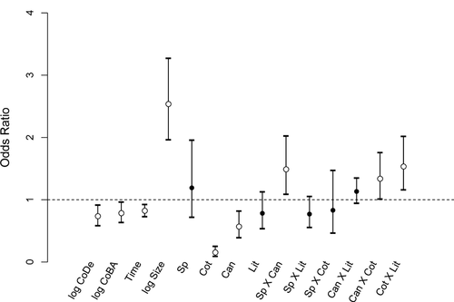

**Figure 1**

Odds ratios estimation (with 95% confidence limit) for model 3. This model had the greatest number of parameters among the most plausible models evaluating the effects of abiotic and biotic variables on survival of early-stage individuals (details in Table 2). Open circles denote odds ratios significantly different from 1 (95% CL do not overlap 1). Species factor is related with the distinction between species, with *Guapira* – the canopy species – as the baseline level for the factor. See Table 2 for variable abbreviations.

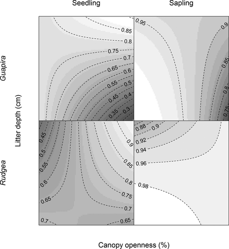

**Figure 2**

Survival predicted by model 3, one of the best-fit models (details on Table 2) for seedlings and saplings of both species as a function of litter depth and percent of canopy openness. The highest survival is found in the lightest areas of the graph.

## Discussion

That light is one of the abiotic factors defining the regeneration niches of tropical tree species is widely recognized (*e.g*., Denslow 1980, Augspurger 1984, Kobe 1999, Montgomery & Chazdon 2002), as is that it contributes to species coexistence and the maintenance of tropical forest diversity (Kobe 1999, Montgomery & Chazdon 2002). We found our two focal species had unique responses to light consistent with these observations. Interestingly, the survival of early-stage *Guapira* individuals was negatively affected by an increase in light availability, despite the fact that it is a canopy species with intermediate light requirements that grows well in both gaps and on forest edges (Gandolfi 2000). In contrast, seedlings of the understory species (*Rudgea*), which occurs in both edges and gaps as well as dense shade (Gandolfi 2000, Catharino *et al*. 2006), showed the expected positive response in survival with increasing light availability (Kobe 1999, Poorter 1999). The mechanism underlying the unexpected results for *Guapira* remains unclear but could include greater herbivory, which appears to be greater under higher light conditions (C. F. Jurinitz, pers. obs.). Such differential herbivory along an environmental gradient has been shown to promote the coexistence of phylogenetically related plant species in Amazonian forests (Fine *et al*. 2004). Although our study does not take into account herbivory, our observations at least indicate that the investigation of herbivory along light gradients is a promising theme to understand the mechanisms underlying successful establishment and consequently species coexistence in these forests.

In contrast to light availability, the effect of litter depth on survival was independent of species but also dependent on ontogenetic stage. Nevertheless, such results are seldom reported, likely due to the exclusion of the cotyledon phase from minimum size criteria in the majority of studies on tropical seedlings (*e.g*., Norden *et al*. 2007, Comita *et al*. 2009, Lin *et al*. 2012). Our results demonstrate that such exclusion may ignore important processes occurring in forest understory, which may help explain important bottlenecks for tropical tree's early life stages, particularly for species with epigeal cotyledons as those studied here. The negative effect of litter depth on the survival of saplings we observed may be attributed to an increase in damage by herbivores and pathogens (García-Guzmán & Benítez-Malvido 2003) or by physical damage caused by litterfall (Scariot 2000, Gillmann *et al*. 2004). The former has been demonstrated experimentally for some tropical tree species (Benitez-Malvido 1998, Benitez-Malvido & Kossmann-Ferraz 1999, García-Guzmán & Benítez-Malvido 2003), while pathogen attack has been seen to increase with increasing litter depth (Benitez-Malvido & Kossmann-Ferraz 1999). The incidence of pathogenic fungi may be conditioned by the presence of litter and its capacity for moisture retention, which in turn affects survival (Facelli 1999). In contrast, litter depth had a positive effect on survival of seedlings. Among the known positive effects of litter are escape from herbivores (Cintra 1997), increase in nutrient availability from litter decomposition (Brearley *et al*. 2003), and protection against desiccation (Molofsky & Augspurger 1992, Seiwa & Kikuzawa 1996). Such moisture retention may explain the enhanced performance of the shade tolerant tree *Gustavia superba* in deep litter (Molofsky & Augspurger 1992), as well as that of small-seeded deciduous broad-leaved tree species in gaps relative to those in the forest understory (Seiwa & Kikuzawa 1996). In addition, field observations showed that seedlings, especially those of the understory species, were able to survive below the litter layer for a while (C.F. Jurinitz, pers. obs.), which supports the explanation of protection against desiccation or herbivory. At this early developmental stage, the litter layer likely mainly acts to attenuate the light that reaches the seedlings (Vazquez-Yanes *et al*. 1990). It is likely that this light attenuation, although it could cause negative effects, is not sufficient to lead to a decrease in survival. Indeed, it could even benefit seedlings by creating better microclimatic conditions or escape from herbivores (*i.e*., the balance among these two contrasting effects would be positive).

Our results highlight the value of understanding the effects of natural variation in litter depth and canopy openness and demonstrate that this kind of observational study can be a good alternative to contrasting treatments such as with versus without litter, or gap versus non-gap, employed in field experiments (Seiwa & Kikuzawa 1996, Makana & Thomas 2005, Seiwa 2007) or controlled experimental conditions in greenhouses (revised by Sayer 2006). Treatments of contrasting light conditions (especially in greenhouses) may be responsible for the predominance of a light response when light and litter were evaluated together for shade-tolerant plants (Seiwa 2007). Likewise, in a meta-analysis of the effects of litter on vegetation (germination, establishment, species richness, and aboveground biomass), vegetation was more affected, on average, by litter in field studies than in those performed in greenhouses (Xiong & Nilsson 1999). The results of these studies reinforce the importance of observational approaches like ours to elucidate processes occurring in the forest understory.

As expected, we found a significant effect of conspecific density dependence, in agreement with several studies in tropical forests worldwide (*e.g*., Comita & Hubbell 2009, Comita *et al*. 2009, 2010, Lin *et al*. 2012). Negative density dependence is considered a pervasive mechanism that contributes to the maintenance of diversity in tropical tree communities, probably via differential attack by natural host-specific enemies, such as seed predators, herbivores, and pathogens (Connell 1970, Janzen 1970, Harms *et al*. 2000). It has also been suggested that conspecific density-dependence shapes species abundances in diverse communities (Comita *et al*. 2010). It has been posited that rare species may suffer more from the presence of conspecific neighbors than common species (Comita *et al*. 2010); nevertheless, our results demonstrate that the negative conspecific density-dependence effect was strong for two locally abundant species.

Our findings have important implications for early-stage individuals of tropical tree species, especially shade-tolerant species with epigeal cotyledons. We confirm light availability is an important factor for defining the segregation of regeneration niches. Considering all the significant factors influencing early-stage survival, the conditions that favor survival for the canopy species include locations with low conspecific density and light availability, combined with a deep (seedlings) or a shallow (saplings) litter layer. For the understory species, favorable conditions for regeneration include locations where the conspecific density is reduced, light availability is relatively high, and there is a deep litter layer – for seedlings, or, alternatively, places with low light availability combined with a shallow litter layer – for saplings.

Our results also highlight the importance of ontogeny for understanding the factors that influence early-stage survival. Many studies define seedlings as all individuals up to a certain size, often ignoring the striking ecophysiological differences related to the presence of cotyledons. We show that this can prevent the detection of important processes that change along early-stage ontogeny. These findings parallel those observed in temperate forests (Lusk 2004) and suggest that explicit consideration of the responses of different ontogenetic stages is necessary to advance our understanding of microhabitat partitioning in tropical forests.

## Acknowledgments

We thank the researchers and technicians from Laboratório de Ecologia da Paisagem e Conservação (LEPaC) of Universidade de São Paulo, for the selection of study areas and facilitation of their access. We are grateful to the landowners for giving their permission to conduct the study. We thank everybody that provided field assistance, especially Marcel Caritá Vaz and Juliana Lopes Vendrami. We thank Christine Lucas for comments on the manuscript and grammatical revisions. Anselmo Nogueira and Marcel Caritá Vaz also contributed with valuable comments. In addition, the article was greatly improved by the comments and suggestions of Saara DeWalt and five anonymous reviewers. The Fundação de Amparo à Pesquisa do Estado de São Paulo (FAPESP) (process number 2005/54782-3 – scholarship for the first author, and process number 2006/56054-8 – project grant) provided financial support and the German Federal Ministry of Education and Research (BMBF) (project ID 01 LB 0202) provided logistic support.